# Livestock Growth Modelling Analysis

Yusuf Omotosho

2024-05-23

### Project Overview

This project was conducted for the Department of Animal Breeding & Genetics at the University of Ibadan. The study focused on modeling livestock growth performance using non-linear regression models to analyze growth patterns of Holstein Friesian and F1 crossbred cattle. The analysis provided insights for improved livestock management.

**Objectives:**

- Assess growth performance using non-linear regression models.
- Estimate model parameters and compare growth patterns.
- Provide data-driven recommendations for livestock management.

**Tools & Libraries Used**

- R Packages: nls, minpack.lm, ggplot2, dplyr, readxl
- Software: R, Excel
- Statistical Methods: AIC, BIC, R-squared

### Install and Load Packages

```r
# STEP 2 : Load necessary libraries
library(nlme)
library(minpack.lm)
library(ggplot2)
library(dplyr)
library(readxl)
library(tidyr)
library(purrr)
```

### Data and Methodology

**1. Data Source and Structure :**

```r
# Load dataset
cattle_data <- read_excel("cattle_dataset.xlsx")

# Display a preview of the dataset
print(head(cattle_data))
```

```
## # A tibble: 6 × 4
##      ID Age_Months Breed_Group Weight_Kg
##   <dbl>      <dbl> <chr>           <dbl>
## 1     1        5.5 HYBRID           93.7
## 2     2        6   HYBRID           95.1
## 3     3        6.5 HYBRID          100
## 4     4        7   HYBRID          109.
## 5     5        7.5 HYBRID          110.
## 6     6        8   HYBRID          120.
```

```r
# Inspect the structure of the dataset
cat("\nStructure of the Data:\n")
```

```
##
## Structure of the Data:
```

```r
str(cattle_data)
```

```
## tibble [79 × 4] (S3: tbl_df/tbl/data.frame)
##  $ ID         : num [1:79] 1 2 3 4 5 6 7 8 9 10 ...
##  $ Age_Months : num [1:79] 5.5 6 6.5 7 7.5 8 8.5 9 9.5 10 ...
##  $ Breed_Group: chr [1:79] "HYBRID" "HYBRID" "HYBRID" "HYBRID" ...
##  $ Weight_Kg  : num [1:79] 93.7 95.1 100 109.3 110.3 ...
```

```r
# Summary statistics for each variable
cat("\nSummary Statistics for Each Variable:\n")
```

```
##
## Summary Statistics for Each Variable:
```

```r
print(summary(cattle_data))
```

```
##        ID         Age_Months    Breed_Group          Weight_Kg
##  Min.   : 1.0   Min.   : 5.50   Length:79          Min.   : 93.73
##  1st Qu.:20.5   1st Qu.:10.50   Class :character   1st Qu.:157.26
##  Median :40.0   Median :15.50   Mode  :character   Median :220.02
##  Mean   :40.0   Mean   :15.40                      Mean   :213.43
##  3rd Qu.:59.5   3rd Qu.:20.25                      3rd Qu.:262.75
##  Max.   :79.0   Max.   :26.00                      Max.   :325.33
```

[output not shown]

[output not shown]

**2. Data Quality Checks**

```r
# Display any rows with non-finite values for diagnostic purposes
non_finite_rows <- cattle_data %>%
  filter(
    !is.finite(Age_Months) |  # Check for non-finite Age
    !is.finite(Weight_Kg) # Check for non-finite Weight
  )

if (nrow(non_finite_rows) > 0) {
  message("Non-finite values detected. Below are the rows with issues:")
  print(non_finite_rows)
} else {
  message("No non-finite values detected.")
}
```

```
## No non-finite values detected.
```

```r
# Check for missing values
cat("Missing Values:\n")
```

```
## Missing Values:
```

```r
print(colSums(is.na(cattle_data)))
```

```
##          ID  Age_Months Breed_Group   Weight_Kg
##           0           0           0           0
```

```r
# Check for duplicate rows
cat("Duplicate Rows:\n")
```

```
## Duplicate Rows:
```

```r
print(nrow(cattle_data) - nrow(distinct(cattle_data)))
```

```
## [1] 0
```

```r
# Check for outliers using Z-score method
z_scores_Weight <- scale(cattle_data$Weight_Kg)
outliers_Weight <- which(abs(z_scores_Weight) > 3)
cat("Outliers Detected (Weight):\n")
```

```
## Outliers Detected (Weight):
```

```r
print(outliers_Weight)
```

```
## integer(0)
```

```r
z_scores_age <- scale(cattle_data$Age_Months)
outliers_age <- which(abs(z_scores_age) > 3)
cat("Outliers Detected (Age):\n")
```

```
## Outliers Detected (Age):
```

```r
print(outliers_age)
```

```
## integer(0)
```

### Growth Curve Modeling

**Where:**

- ‘Y(t)’ is the population mean at time t.
- ‘A’ is the asymptotic weight or maximum value.
- ‘B’ is the proportion of asymptotic weight to be gained after birth.
- ‘k’ is the maturity rate.
- ‘t’ is time.

**1. Model Fitting**

```r
# Define growth model equations
brody_model <- function(Age_Months, A, B, k) A * (1 - B * exp(-k * Age_Months))
vonB_model <- function(Age_Months, A, B, k) A * (1 - exp(-k * Age_Months))^B
log_model <- function(Age_Months, A, B, k) A / (1 + B * exp(-k * Age_Months))
```

**2. Fit models by Breed Type**

```r
# Fit models for each group
# Function to fit model
fit_model <- function(model_func, data) {
  nlsLM(Weight_Kg ~ model_func(Age_Months, A, B, k),
        data = data,
        start = list(A = 730, B = 0.5, k = 0.01),
        control = nls.lm.control(maxiter = 1000))
}

# Split data into a list of data frames by Breed_Group
cattle_list <- split(cattle_data, cattle_data$Breed_Group)

# Apply models separately for each breed group
fits <- lapply(cattle_list, function(df) {
  list(
    brody = fit_model(brody_model, df),
    vonB = fit_model(vonB_model, df),
    log = fit_model(log_model, df)
  )
})

# Name the list elements based on breed groups
names(fits) <- names(cattle_list)

# Print results
print(fits)
```

```
## $HYBRID
## $HYBRID$brody
## Nonlinear regression model
##   model: Weight_Kg ~ model_func(Age_Months, A, B, k)
##    data: data
##         A         B         k
## 730.55590   1.00336   0.02282
##  residual sum-of-squares: 4348
##
## Number of iterations to convergence: 7
## Achieved convergence tolerance: 1.49e-08
##
## $HYBRID$vonB
## Nonlinear regression model
##   model: Weight_Kg ~ model_func(Age_Months, A, B, k)
##    data: data
##         A         B         k
## 618.84906   1.07786   0.03057
##  residual sum-of-squares: 4324
##
## Number of iterations to convergence: 23
## Achieved convergence tolerance: 1.49e-08
##
## $HYBRID$log
## Nonlinear regression model
##   model: Weight_Kg ~ model_func(Age_Months, A, B, k)
##    data: data
##        A        B        k
## 348.4157   6.8786   0.1573
##  residual sum-of-squares: 3722
##
## Number of iterations to convergence: 10
## Achieved convergence tolerance: 1.49e-08
##
##
## $`PURE BREED`
## $`PURE BREED`$brody
## Nonlinear regression model
##   model: Weight_Kg ~ model_func(Age_Months, A, B, k)
##    data: data
```

[output cut: 13 more lines]

```
##  residual sum-of-squares: 5817
##
## Number of iterations to convergence: 19
## Achieved convergence tolerance: 1.49e-08
##
## $`PURE BREED`$log
## Nonlinear regression model
##   model: Weight_Kg ~ model_func(Age_Months, A, B, k)
##    data: data
##        A        B        k
## 305.9332   5.0145   0.1776
##  residual sum-of-squares: 5018
##
## Number of iterations to convergence: 12
## Achieved convergence tolerance: 1.49e-08
```

**3. Parameter Estimation**

```r
# Function to extract coefficients from the fitted model
extract_params <- function(model) {
  as.data.frame(summary(model)$coefficients)  # Convert to a structured data frame
}

# Extract parameters for all models
params <- lapply(fits, function(models) {
  list(
    brody = extract_params(models$brody),
    vonB  = extract_params(models$vonB),
    log   = extract_params(models$log)
  )
})

# Convert list structure to a data frame
params_df <- do.call(rbind, lapply(names(params), function(name) {
  data.frame(
    Breed_Group  = name,
    brody_params = paste(capture.output(print(params[[name]]$brody)), collapse = " "),
    vonB_params  = paste(capture.output(print(params[[name]]$vonB)), collapse = " "),
    log_params   = paste(capture.output(print(params[[name]]$log)), collapse = " ")
  )
}))

# Print the formatted results
print(params_df)
```

```
##   Breed_Group
## 1      HYBRID
## 2  PURE BREED
##                                                                                                                                                                                                  brody_params
## 1       Estimate   Std. Error   t value     Pr(>|t|) A 730.55589527 259.71471266  2.812917 7.997254e-03 B   1.00335982   0.02323613 43.181015 5.959711e-32 k   0.02281895   0.01124960  2.028422 5.018033e-02
## 2           Estimate  Std. Error   t value     Pr(>|t|) A 352.17094739 24.36872407 14.451760 5.047565e-17 B   1.08457776  0.08379218 12.943664 1.667520e-15 k   0.07366305  0.01412443  5.215295 6.764354e-06
##                                                                                                                                                                                               vonB_params
## 1       Estimate   Std. Error  t value     Pr(>|t|) A 618.84906003 244.20818956 2.534104 1.590325e-02 B   1.07785827   0.17592449 6.126823 5.257619e-07 k   0.03056941   0.02069793 1.476931 1.486363e-01
## 2       Estimate  Std. Error   t value     Pr(>|t|) A 337.39418923 22.70875709 14.857449 2.056798e-17 B   1.32025574  0.24421271  5.406171 3.711097e-06 k   0.08956379  0.02105151  4.254506 1.317719e-04
##                                                                                                                                                                                        log_params
## 1      Estimate  Std. Error  t value     Pr(>|t|) A 348.4157004 16.55633246 21.04426 1.887191e-21 B   6.8786053  0.54901654 12.52896 1.707448e-14 k   0.1572669  0.01303892 12.06135 5.066185e-14
## 2          Estimate Std. Error  t value     Pr(>|t|) A 305.9332411 8.38926899 36.46721 3.516510e-31 B   5.0144636 0.62804834  7.98420 1.195100e-09 k   0.1775674 0.01617134 10.98038 2.382769e-13
```

### Model Comparison

**Assessment Criteria** - ‘AIC (Akaike Information Criterion) - ’BIC’ (Bayesian Information Criterion) - ‘R-squared’

**1. Retrieve residuals and fitted values:**

```r
# Function to compare models and extract AIC, BIC, and R²
compare_models <- function(model) {
  # Handle errors and non-converged models safely
  result <- tryCatch({
    if (!model$convInfo$isConv) return(c(AIC = NA, BIC = NA, R2 = NA))

    residuals <- model$m$resid()
    fitted <- model$m$fitted()
    actuals <- fitted + residuals

    AIC_val <- AIC(model)
    BIC_val <- BIC(model)
    R2_val <- 1 - sum(residuals^2) / sum((actuals - mean(actuals))^2)

    return(c(AIC = AIC_val, BIC = BIC_val, R2 = R2_val))
  }, error = function(e) {
    return(c(AIC = NA, BIC = NA, R2 = NA))
  })

  return(result)
}

# Apply `compare_models()` to each model in `fits`
model_metrics <- do.call(rbind, lapply(names(fits), function(name) {
  data.frame(
    Breed_Group   = name,
    brody_AIC     = compare_models(fits[[name]]$brody)["AIC"],
    brody_BIC     = compare_models(fits[[name]]$brody)["BIC"],
    brody_R2      = compare_models(fits[[name]]$brody)["R2"],
    vonB_AIC      = compare_models(fits[[name]]$vonB)["AIC"],
    vonB_BIC      = compare_models(fits[[name]]$vonB)["BIC"],
    vonB_R2       = compare_models(fits[[name]]$vonB)["R2"],
    log_AIC       = compare_models(fits[[name]]$log)["AIC"],
    log_BIC       = compare_models(fits[[name]]$log)["BIC"],
    log_R2        = compare_models(fits[[name]]$log)["R2"]
  )
}))

# Convert to a clean data frame
model_metrics <- as.data.frame(model_metrics)

# Print results
print(model_metrics)
```

```
##      Breed_Group brody_AIC brody_BIC  brody_R2 vonB_AIC vonB_BIC   vonB_R2
## AIC       HYBRID  295.9560  302.5063 0.9743366 295.7485 302.2988 0.9744764
## AIC1  PURE BREED  328.4821  335.3364 0.9544818 327.5040 334.3582 0.9555548
##       log_AIC  log_BIC    log_R2
## AIC  290.0514 296.6018 0.9780299
## AIC1 321.4479 328.3021 0.9616580
```

**2. Check for Non-convergence**

```r
# Function to check convergence
check_convergence <- function(model) {
  if (is.null(model)) return(data.frame(Status = "Error: Model is NULL"))

  conv_info <- tryCatch(model$convInfo, error = function(e) NULL)
  if (is.null(conv_info)) return(data.frame(Status = "Error: No convergence info"))

  residuals <- tryCatch(residuals(model), error = function(e) NA)
  fitted <- tryCatch(fitted(model), error = function(e) NA)
  actuals <- fitted + residuals

  # Calculate R2 if residuals and fitted values are valid
  R2 <- if (!anyNA(residuals) && !anyNA(fitted)) {
    1 - sum(residuals^2) / sum((actuals - mean(actuals))^2)
  } else {
    NA
  }

  # Return details as a data frame
  data.frame(
    Status = if (conv_info$isConv) "Converged" else "Not Converged",
    Iterations = conv_info$finIter,
    Tolerance = conv_info$finTol,
    StopCode = conv_info$stopCode,
    StopMessage = conv_info$stopMessage,
    R2 = R2
  )
}

# Function to extract coefficients
extract_coefficients <- function(model) {
  coef_values <- tryCatch(coef(model), error = function(e) NA)
  if (is.numeric(coef_values)) {
    return(as.list(coef_values))  # Return a named list for easier mapping
  } else {
    return(list(NA))  # Handle cases where coefficients cannot be extracted
  }
}

# Apply convergence checks and extract details
convergence_results <- map_dfr(names(fits), function(name) {
  brody_conv <- check_convergence(fits[[name]]$brody)
  vonB_conv  <- check_convergence(fits[[name]]$vonB)
  log_conv   <- check_convergence(fits[[name]]$log)

  brody_coeff <- extract_coefficients(fits[[name]]$brody)
  vonB_coeff  <- extract_coefficients(fits[[name]]$vonB)
  log_coeff   <- extract_coefficients(fits[[name]]$log)

  data.frame(
    Breed_Group   = name,
    Brody_Status  = brody_conv$Status,
    Brody_Iter    = brody_conv$Iterations,
    Brody_Tol     = brody_conv$Tolerance,
    Brody_Stop    = brody_conv$StopCode,
    Brody_R2      = brody_conv$R2,
    VonB_Status   = vonB_conv$Status,
    VonB_Iter     = vonB_conv$Iterations,
    VonB_Tol      = vonB_conv$Tolerance,
    VonB_Stop     = vonB_conv$StopCode,
    VonB_R2       = vonB_conv$R2,
    Log_Status    = log_conv$Status,
    Log_Iter      = log_conv$Iterations,
    Log_Tol       = log_conv$Tolerance,
    Log_Stop      = log_conv$StopCode,
    Log_R2        = log_conv$R2
  ) %>%
    bind_cols(as.data.frame(t(unlist(brody_coeff))), .) %>%
    bind_cols(as.data.frame(t(unlist(vonB_coeff))), .) %>%
    bind_cols(as.data.frame(t(unlist(log_coeff))), .)
})
# Convert to a clean data frame
convergence_results <- as.data.frame(convergence_results)

# Print results
print(convergence_results)
```

```
##      A...1    B...2     k...3    A...4    B...5      k...6    A...7    B...8
## 1 348.4157 6.878605 0.1572669 618.8491 1.077858 0.03056941 730.5559 1.003360
## 2 305.9332 5.014464 0.1775674 337.3942 1.320256 0.08956379 352.1709 1.084578
##        k...9 Breed_Group Brody_Status Brody_Iter    Brody_Tol Brody_Stop
## 1 0.02281895      HYBRID    Converged          7 1.490116e-08          1
## 2 0.07366305  PURE BREED    Converged         13 1.490116e-08          1
##    Brody_R2 VonB_Status VonB_Iter     VonB_Tol VonB_Stop   VonB_R2 Log_Status
## 1 0.9743366   Converged        23 1.490116e-08         1 0.9744764  Converged
## 2 0.9544818   Converged        19 1.490116e-08         1 0.9555548  Converged
##   Log_Iter      Log_Tol Log_Stop    Log_R2
## 1       10 1.490116e-08        1 0.9780299
## 2       12 1.490116e-08        1 0.9616580
```

### Visualization

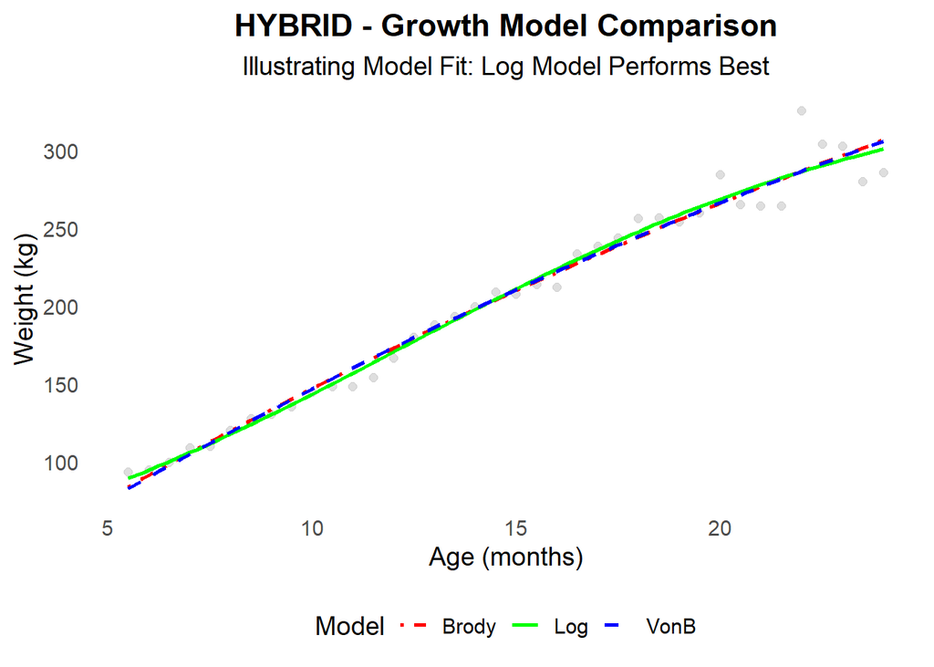

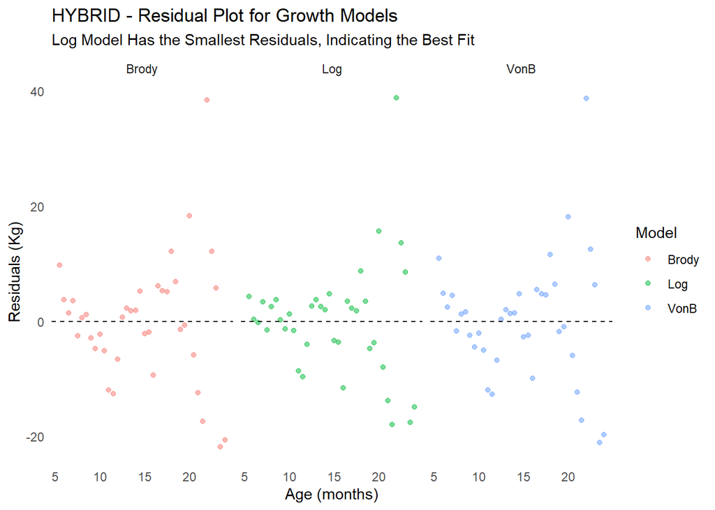

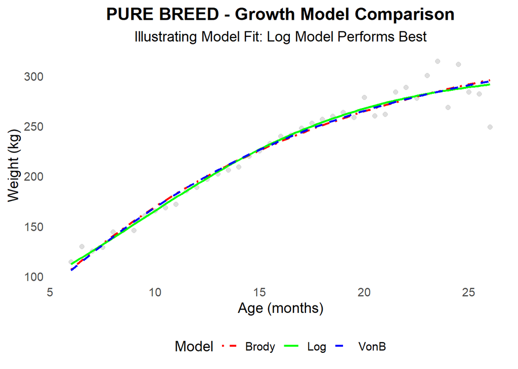

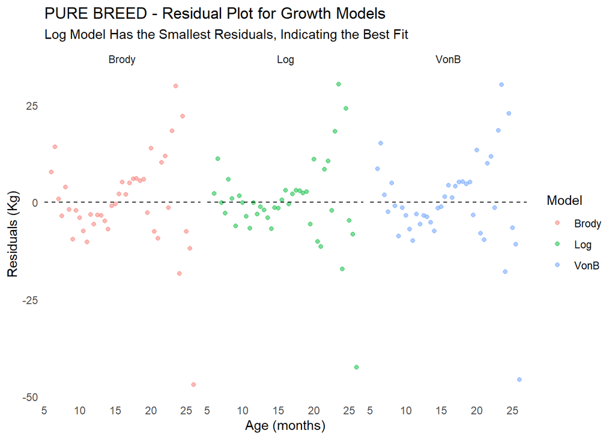

```r
# Function to plot all three models together for each breed
plot_growth_comparison <- function(fit, data, breed) {
  # Filter observed data for the specific breed
  observed_data <- data %>%
    filter(Breed_Group == breed)

  pred_data <- data.frame(Age_Months = seq(min(observed_data$Age_Months), max(observed_data$Age_Months), length.out = 100))

  # Generate predictions for each model
  pred_data$Brody <- predict(fit$brody, newdata = pred_data)
  pred_data$VonB <- predict(fit$vonB, newdata = pred_data)
  pred_data$Log <- predict(fit$log, newdata = pred_data)

  # Convert to long format for ggplot
  pred_data_long <- pred_data %>%
    pivot_longer(cols = c(Brody, VonB, Log), names_to = "Model", values_to = "Weight_Kg")

  # Create plot
  ggplot() +
    # Observed Data (Filtered to the Specific Breed)
    geom_point(data = observed_data, aes(x = Age_Months, y = Weight_Kg), size = 2, alpha = 0.5, color = "grey") +

    # Model Predictions
    geom_line(data = pred_data_long, aes(x = Age_Months, y = Weight_Kg, color = Model, linetype = Model), linewidth = 1) +

    scale_color_manual(values = c("red", "green", "blue")) +
    scale_linetype_manual(values = c("dotdash", "solid", "dashed")) +
    labs(
      title = paste(breed, "- Growth Model Comparison"),
      subtitle = "Illustrating Model Fit: Log Model Performs Best",
      x = "Age (months)", y = "Weight (kg)",
      color = "Model",
      linetype = "Model"
    ) +
    theme_minimal(base_size = 14) +
    theme(
      plot.title = element_text(hjust = 0.5, face = "bold"),
      plot.subtitle = element_text(hjust = 0.5),
      legend.position = "bottom",
      panel.grid = element_blank()
    )
}

# Function to plot residuals for each model
plot_residuals <- function(fit, data, breed) {
  # Filter observed data for the specific breed
  observed_data <- data %>%
    filter(Breed_Group == breed)

  # Compute residuals for each model
  observed_data$Residual_Brody <- observed_data$Weight_Kg - predict(fit$brody, newdata = observed_data)
  observed_data$Residual_VonB <- observed_data$Weight_Kg - predict(fit$vonB, newdata = observed_data)
  observed_data$Residual_Log <- observed_data$Weight_Kg - predict(fit$log, newdata = observed_data)

  # Convert to long format
  residuals_long <- observed_data %>%
    pivot_longer(cols = starts_with("Residual_"), names_to = "Model", values_to = "Residuals") %>%
    mutate(Model = gsub("Residual_", "", Model))

  # Create residual plot
  ggplot(residuals_long, aes(x = Age_Months, y = Residuals, color = Model)) +
    geom_point(alpha = 0.5) +
    geom_hline(yintercept = 0, linetype = "dashed") +
    facet_wrap(~Model) +
    labs(
      title = paste(breed, "- Residual Plot for Growth Models"),
      subtitle = "Log Model Has the Smallest Residuals, Indicating the Best Fit",
      x = "Age (months)", y = "Residuals (Kg)"
    ) +
    theme_minimal() +
    theme(panel.grid = element_blank())
}

# --- FUNCTION TO PLOT COMBINED GROWTH MODELS ACROSS BREEDS --- #
plot_combined_growth_models <- function(fits, data) {
  combined_data <- map_dfr(names(fits), function(breed) {
    pred_data <- data.frame(Age_Months = seq(min(data$Age_Months), max(data$Age_Months), length.out = 100))
    pred_data$Brody <- predict(fits[[breed]]$brody, newdata = pred_data)
    pred_data$VonB <- predict(fits[[breed]]$vonB, newdata = pred_data)
    pred_data$Log <- predict(fits[[breed]]$log, newdata = pred_data)
    pred_data$Breed <- breed

    pred_data %>%
      pivot_longer(cols = c(Brody, VonB, Log), names_to = "Model", values_to = "Weight_Kg")
  })

  # Create observed data subset with renamed breed group
  observed_data <- data %>%
    mutate(Breed = Breed_Group) %>%
    group_by(Breed)

  # Create combined plot
  ggplot() +
    # Model Predictions (colored lines)
    geom_line(data = combined_data, aes(x = Age_Months, y = Weight_Kg, color = Model, linetype = Model), linewidth = 1) +

    # Observed Data (black points for comparison)
    geom_point(data = observed_data, aes(x = Age_Months, y = Weight_Kg), size = 2, alpha = 0.5, color = "grey") +

    # Facet structure with 2 columns for better layout
    facet_wrap(~Breed, ncol = 2) +

    # Customize appearance
    scale_color_manual(values = c("red", "green", "blue")) +
    scale_linetype_manual(values = c("dotdash", "solid", "dashed")) +
    labs(
      title = "Growth Model Comparison for Hybrid and Pure Breed Cattle",
      subtitle = "Illustrating the Fit of Brody, Von Bertalanffy, and Log Models",
      x = "Age (months)", y = "Weight (kg)",
      color = "Model",
      linetype = "Model"
    ) +

    theme_minimal(base_size = 14) +
    theme(
      plot.title = element_text(hjust = 0.5, face = "bold"),
      plot.subtitle = element_text(hjust = 0.5),
      legend.position = "bottom",
      panel.grid = element_blank()
    )
}

# Generate and print plots for each breed group
walk(names(fits), function(breed) {
  print(plot_growth_comparison(fits[[breed]], cattle_data, breed))
  print(plot_residuals(fits[[breed]], cattle_data, breed))
})
```

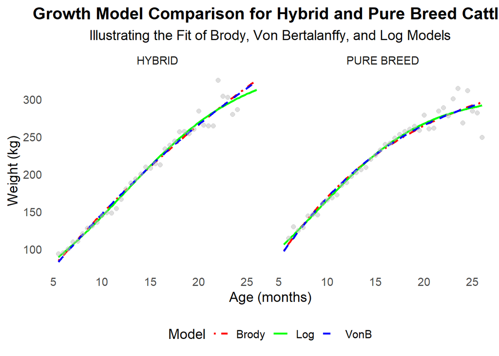

```r
# Generate and print the optimized combined growth model plot
print(plot_combined_growth_models(fits, cattle_data))
```